# Atividade 1

João Pedro

2024-04-11

#### 1. Decomposição Clássica

Considera uma série temporal ${Z_t, t = 1,..., N}$ que pode ser representada como a soma dos componentes:

- `Tendência:` $T_t$, Componente de **Longo Prazo** associado ao movimento da variável no tempo.
- `Ciclo:` $C_t$, Componente de **Médio Prazo** associado a períodos de expansão ou recessão econômica.
- `Sazonalidade:` $S_t$, Componente de **Curto Prazo** associado a variações provocadas por épocas do ano.
- `Resíduos:` $u_t$, Componente que não se pode explicar, aleatório, também denominado **ruído**.

Descrição das Variaveis

- `data:` Períodicidade mensal, dados de Janeiro de 2002 até Fevereiro de 2024
- `prod_industrial:` Produção industrial - indústria geral - quantum - índice (média 2022 = 100) - Instituto Brasileiro de Geografia e Estatística, Pesquisa Industrial Mensal - Produção Física (IBGE/PIM-PF)

**1) A decomposição da série temporal a partir da Média Móvel;**

### Análise da Série Temporal - Técnicas Descritivas

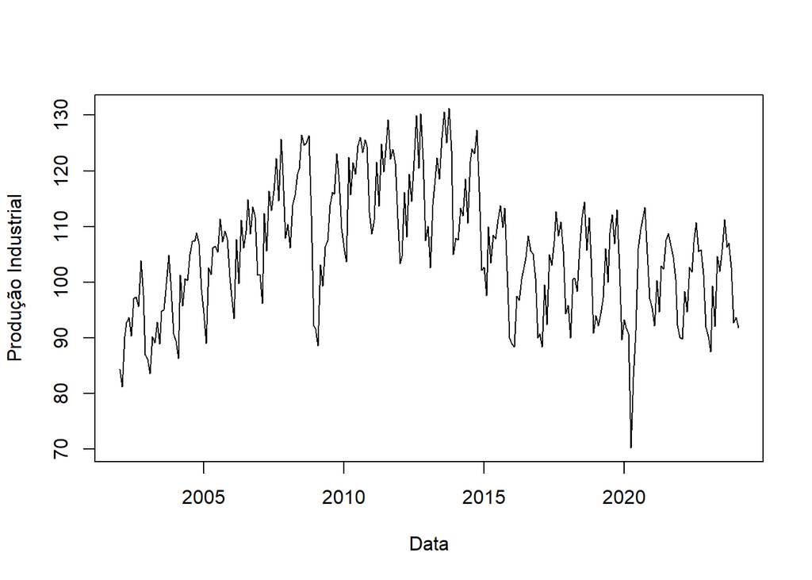

Os dados visualizados apresentam aparente sazonalidade, contudo não é possível inferir sobre a tendência.

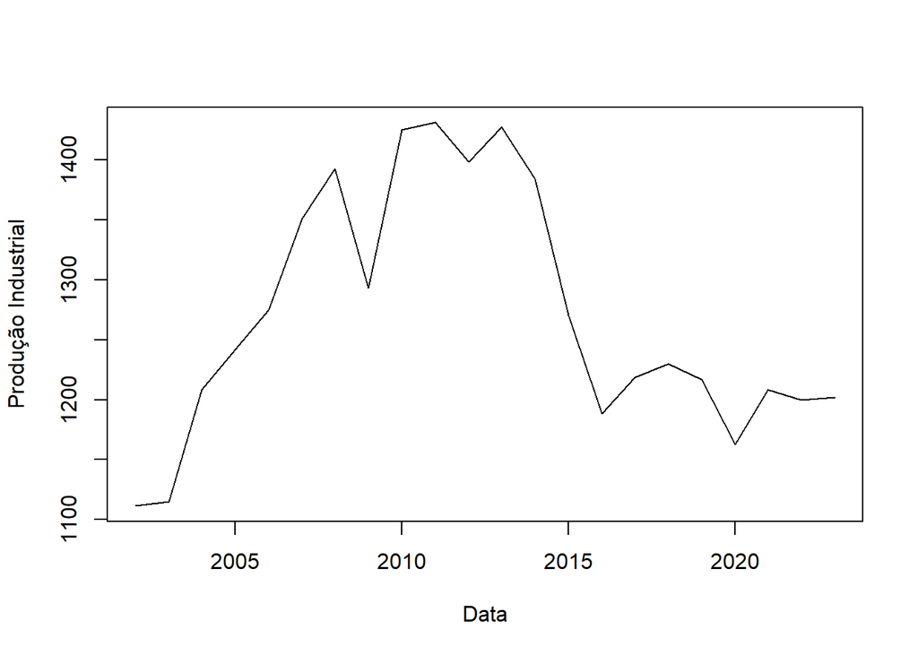

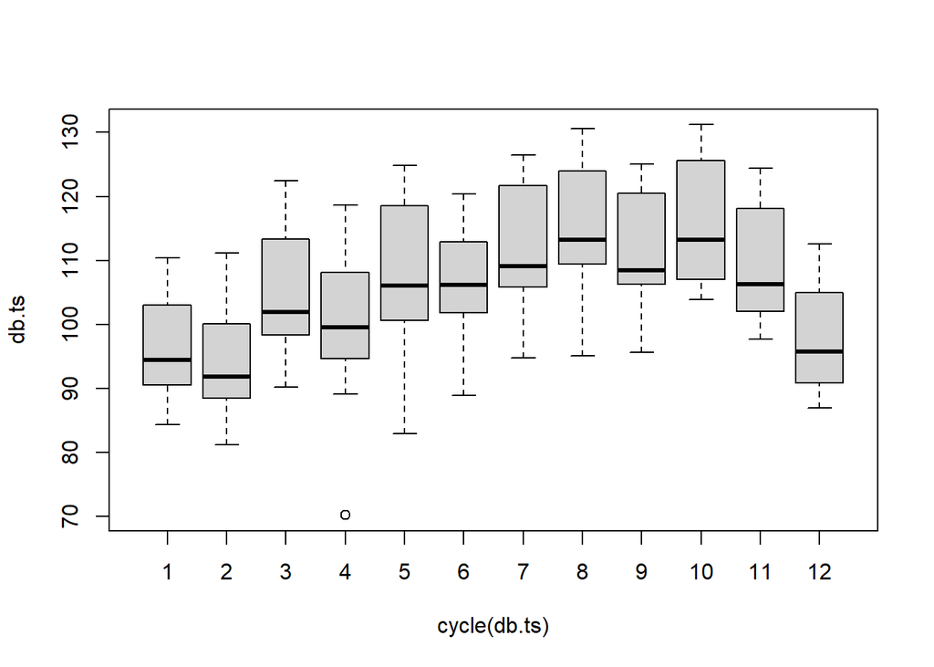

A função cycle nos mostra a posição dos pontos no banco de dados em todo o ciclo, assinando janeiro a 1 e dezembro a 12.

De modo geral quando olhamos para os meses do ano, em especial, a produção é mais intensificada no segundo semestre, com declinio nos ultimos meses do ano.

### Decomposição Clássica

A decomposição de séries temporais é o processo de dividir uma série temporal em componentes individuais, como tendência, sazonalidade, efeitos sazonais e ruído aleatório. Isso ajuda a entender melhor os padrões subjacentes na série temporal.

Considera uma série temporal ${Z_t, t = 1,..., N}$ que pode ser representada como a soma dos componentes:

- `Tendência:` $T_t$, Componente de **Longo Prazo** associado ao movimento da variável no tempo.
- `Ciclo:` $C_t$, Componente de **Médio Prazo** associado a períodos de expansão ou recessão econômica.
- `Sazonalidade:` $S_t$, Componente de **Curto Prazo** associado a variações provocadas por épocas do ano.
- `Resíduos:` $u_t$, Componente que não se pode explicar, aleatório, também denominado **ruído**.

A média móvel é uma técnica que calcula a média de um número específico de observações consecutivas em torno de cada ponto na série temporal. Isso ajuda a suavizar flutuações aleatórias e destacar tendências de longo prazo ou padrões sazonais.

O número específico de valores utilizados na média móvel (conhecido como janela ou período) determina o grau de suavização aplicado à série temporal. Um período maior resultará em uma suavização mais forte, enquanto um período menor capturará variações de curto prazo com mais detalhes. A função decompose estima tendência e efeito sazonal usando a decomposição com o método de médias moveis, que podemos definir como:

$$\text{Média Móvel}_{t}^{(k)} = \frac{1}{k} \sum_{i = t - k + 1}^{t}
x_{i}$$
Onde a Média Movel no tempo $t$, $k$ sendo a janela para a média movel e $x_i$ sendo os pontos da série em um tempo $i$

O modelo `Aditivo`, condiz com variância estabilizada no tempo, logo, **Homocedástico**

$$Z_t = T_t + S_t + C_t + u_t$$

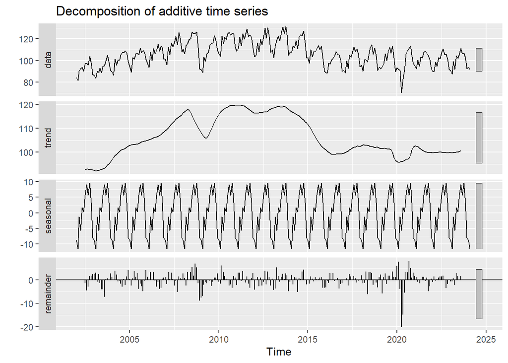

```r
autoplot(decompose(db.ts, type = "additive"))
```

```r
db.ts.decomp.add <- decompose(db.ts, type = "additive")
```

```r
db.ts.decom.add.sazonal <- db.ts.decomp.add$seasonal
knitr::kable(head(db.ts.decom.add.sazonal), align = "c")
```

| x |
| --- |
| -8.7781117 |
| -11.5800384 |
| -1.2216090 |
| -5.6571303 |
| 1.6662250 |
| 0.2669065 |

```r
db.ts.decom.add.trend <- db.ts.decomp.add$trend
knitr::kable(head(db.ts.decom.add.trend, 10), align = "c")
```

| x |
| --- |
| NA |
| NA |
| NA |
| NA |
| NA |
| NA |
| 92.68950 |
| 92.86698 |
| 92.96805 |
| 92.81963 |

```r
db.ts.decom.add.random <- db.ts.decomp.add$random
knitr::kable(head(db.ts.decom.add.random, 10), align = "c")
```

| x |
| --- |
| NA |
| NA |
| NA |
| NA |
| NA |
| NA |
| -1.388573 |
| -4.537128 |
| -2.885993 |
| 1.546529 |

```r
db.ts.decom.add.indice.sazonalidade <- db.ts.decomp.add$figure
knitr::kable(head(db.ts.decom.add.indice.sazonalidade), align = "c")
```

| x |
| --- |
| -8.7781117 |
| -11.5800384 |
| -1.2216090 |
| -5.6571303 |
| 1.6662250 |
| 0.2669065 |

```r
db.ts.add.dessazonalizada <- ts(db.ts - db.ts.decom.add.sazonal,  start = c(2002, 1), end = c(2024, 2), freq = 12)
```

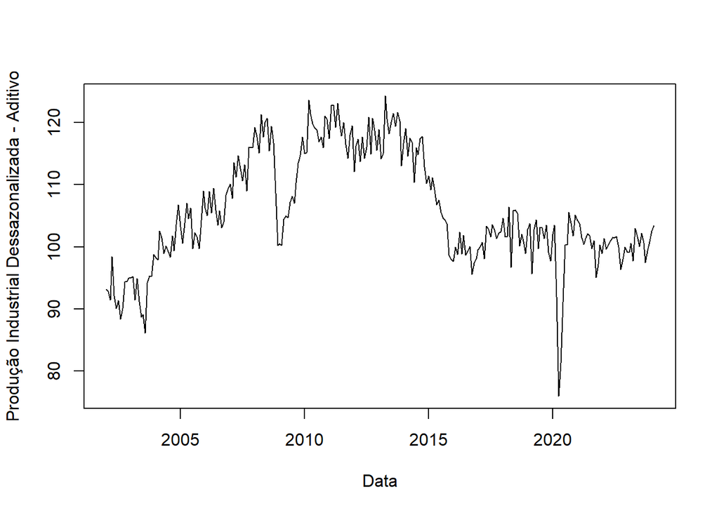

```r
plot(db.ts.add.dessazonalizada, xlab = "Data", ylab = "Produção Industrial Dessazonalizada - Aditivo")
```

Já o modelo `Multiplicativo`, se refere à variância crescente ao longo do tempo, ou seja, **Heterocedástico**

$$Z_t = T_t S_t C_t + u_t$$

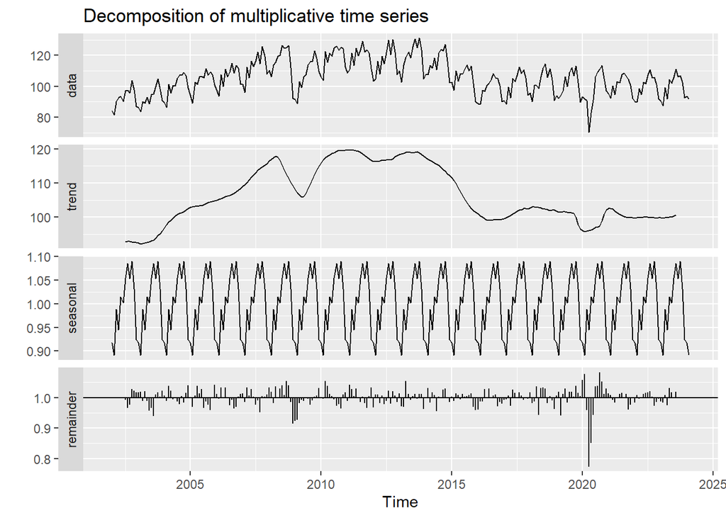

```r
autoplot(decompose(db.ts, type = "multiplicative"))
```

```r
db.ts.decomp.mult <- decompose(db.ts, type = "multiplicative")
```

```r
db.ts.decom.mult.sazonal <- db.ts.decomp.mult$seasonal
knitr::kable(head(db.ts.decom.mult.sazonal), align = "c")
```

| x |
| --- |
| 0.9178114 |
| 0.8912916 |
| 0.9881261 |
| 0.9455048 |
| 1.0147089 |
| 1.0025354 |

```r
db.ts.decom.mult.trend <- db.ts.decomp.mult$trend
knitr::kable(head(db.ts.decom.mult.trend), align = "c")
```

| x |
| --- |
| NA |
| NA |
| NA |
| NA |
| NA |
| NA |

```r
db.ts.decom.mult.random <- db.ts.decomp.mult$random
knitr::kable(head(db.ts.decom.mult.random), align = "c")
```

| x |
| --- |
| NA |
| NA |
| NA |
| NA |
| NA |
| NA |

```r
db.ts.decom.mult.indice.sazonalidade <- db.ts.decomp.mult$figure
knitr::kable(head(db.ts.decom.mult.indice.sazonalidade), align = "c")
```

| x |
| --- |
| 0.9178114 |
| 0.8912916 |
| 0.9881261 |
| 0.9455048 |
| 1.0147089 |
| 1.0025354 |

```r
db.ts.dessazonalizada.mult <- ts(db.ts / db.ts.decom.mult.sazonal,  start = c(2002, 1), end = c(2024, 2), freq = 12)
```

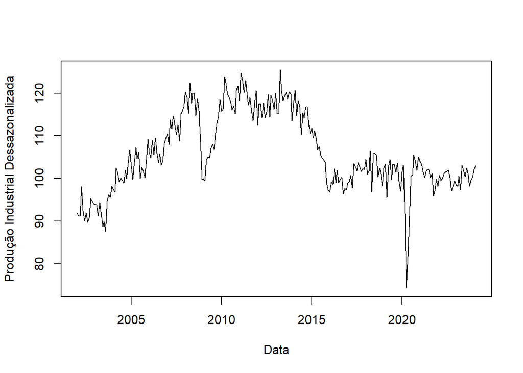

```r
plot(db.ts.dessazonalizada.mult, xlab = "Data", ylab = "Produção Industrial Dessazonalizada")
```

É possível visualizar, tando pelo metodo multiplicativo quando no aditivo, a dessazonalização da série temporal pela média movel, evidência e melhora a percepção das grandes quedas, em especial no ano de 2020 e 2008. Os respectivos períodos explicam a queda da produtividade industrial, o primeiro causado pela crise do SubPrime em 2008 e o segundo pela pandemia do COVID-19.

**2) Considerando a série dessazonalizada obtida do procedimento do item 1), aplique o teste de raiz unitária ADF.**

Uma raiz unitária em uma série temporal indica que a série não é estacionária, o que significa que a média e a variância da série mudam ao longo do tempo. Neste sentido, a estacionaridade é uma caracteristica importante em séries temporais, pois quando está é estacionária, ela possui propriedades estatísticas que são invariantes ao longo do tempo, como média, variância e autocorrelação. Isso simplifica a modelagem e torna mais fácil prever o comportamento futuro da série.

A distinção de uma séria estacionaria ou não estácionaria é feita de maneira formal com o teste ADF (Dickey-Fuller Aumentado), pois este leva em consideração a correlação presente em séries temporais. É possível observar a distribução gráfica e a função de autocorrelação de maneira adicional ao teste.

Considera-se o modelo:

$$Y_t = \rho Y_{t-1} + u_t$$
Quando se tem $/rho = 1$ obtemos o problema de raiz unitária, sendo sinonimo de não estácionariedade. O teste ADF possui três especificações.

$$\begin{align} \Delta y_t &= \color{red}\gamma y_{t-1} +
\underbrace{\sum_{i=2}^{p} \beta_i \Delta y_{t-i+1}}_\text{controle para
correlação serial} + \epsilon_t \\ \rightarrow (\tau1&)\quad H_0 :
\color{red} {\gamma = 0} \\\\ \Delta y_t
&= \color{red}{\gamma} y_{t-1} +
\underbrace{\color{blue}{a_0}}_\text{constante} + \sum_{i=2}^{p} \beta_i
\Delta y_{t-i+1} + \epsilon_t \\ \rightarrow (\phi1&)\quad H_0 :
\color{red} {\gamma = 0} \quad\&\quad\color{blue}{a_0 = 0} \\\
\rightarrow (\tau2&)\quad H_0 : \color{red} {\gamma =
0} \\\ \Delta y_t &= \color{red}{\gamma} y_{t-1} +
\color{blue}{a_0} + \underbrace{\color{green}{a_2} t}_{tendência} +
\sum_{i=2}^{p} \beta_i \Delta y_{t-i+1} + \epsilon_t \\ \rightarrow
(\phi2&)\quad H_0 : \color{red} {\gamma = 0} \quad\&\quad
\color{blue}{a_0 = 0} \quad\&\quad \color{green}{a_2 = 0} \\
\rightarrow (\phi3&)\quad H_0 : \color{red} {\gamma = 0}
\quad\&\quad\color{blue}{a_0 = 0} \\ \rightarrow (\tau3&)\quad
H_0 : \color{red} {\gamma = 0} \end{align}$$
Onde $\tau = 0$ indica presença de raiz unitária. $\phi1 = 0$ ou $\phi3 = 0$ mostra a presença de raiz unitária, contudo, sem a presença de intercepto. Por sua vez, $\phi2 = 0$ evidência a presença de raiz unitária sem a presença de intercepto e tendência, simultaneamente.

Para o teste, temos que se o valor da estatística de teste ADF for menor do que os valores críticos correspondentes, rejeitamos a hipótese nula de presença de raiz unitária e concluímos que a série temporal é estacionária.

A seleção da especificação do teste de raiz unitária depende da natureza da série temporal. Em linhas gerais, quando a série mostra tendência, é consideravel incluir o termo de tendência no teste. Ademais, pode-se utilizar todas as especificações na presença de incerteza e verificar a significancia dos testes.

### Teste ADF em Nível Dessazonalizada

#### Variável em Nível com Drift e Trend

```r
db.ts.adf.trend = ur.df(db.ts.add.dessazonalizada, type = 'trend', lags = 0)
summary(db.ts.adf.trend)
```

```
##
## ###############################################
## # Augmented Dickey-Fuller Test Unit Root Test #
## ###############################################
##
## Test regression trend
##
##
## Call:
## lm(formula = z.diff ~ z.lag.1 + 1 + tt)
##
## Residuals:
##      Min       1Q   Median       3Q      Max
## -17.0735  -1.8417  -0.2076   2.2417   9.9642
##
## Coefficients:
##              Estimate Std. Error t value Pr(>|t|)
## (Intercept)  9.117267   2.600312   3.506 0.000535 ***
## z.lag.1     -0.082907   0.023873  -3.473 0.000602 ***
## tt          -0.002265   0.002820  -0.803 0.422538
## ---
## Signif. codes:  0 '***' 0.001 '**' 0.01 '*' 0.05 '.' 0.1 ' ' 1
##
## Residual standard error: 3.495 on 262 degrees of freedom
## Multiple R-squared:  0.04475,    Adjusted R-squared:  0.03746
## F-statistic: 6.137 on 2 and 262 DF,  p-value: 0.002484
##
##
## Value of test-statistic is: -3.4728 4.1024 6.1373
##
## Critical values for test statistics:
##       1pct  5pct 10pct
## tau3 -3.98 -3.42 -3.13
## phi2  6.15  4.71  4.05
## phi3  8.34  6.30  5.36
```

- Raiz unitária não está presente em $\tau3$ 5% (H0 rejeitada) e está presente em 1% (H0 não rejeitada).
- Raiz unitária está presente em $\phi3$ 1% (Ho não rejeitada) e não há tendência.
- Raiz unitária está presente em $\phi3$ 1% (Ho não rejeitada) e não há tendência nem drift.

```r
db.ts.adf.drift = ur.df(db.ts.add.dessazonalizada, type = 'drift', lags = 0)
summary(db.ts.adf.drift)
```

```
##
## ###############################################
## # Augmented Dickey-Fuller Test Unit Root Test #
## ###############################################
##
## Test regression drift
##
##
## Call:
## lm(formula = z.diff ~ z.lag.1 + 1)
##
## Residuals:
##      Min       1Q   Median       3Q      Max
## -17.2420  -2.0147  -0.2861   2.2253   9.9422
##
## Coefficients:
##             Estimate Std. Error t value Pr(>|t|)
## (Intercept)  8.61572    2.52254   3.415 0.000737 ***
## z.lag.1     -0.08102    0.02374  -3.412 0.000745 ***
## ---
## Signif. codes:  0 '***' 0.001 '**' 0.01 '*' 0.05 '.' 0.1 ' ' 1
##
## Residual standard error: 3.492 on 263 degrees of freedom
## Multiple R-squared:  0.0424, Adjusted R-squared:  0.03876
## F-statistic: 11.64 on 1 and 263 DF,  p-value: 0.0007452
##
##
## Value of test-statistic is: -3.4125 5.8389
##
## Critical values for test statistics:
##       1pct  5pct 10pct
## tau2 -3.44 -2.87 -2.57
## phi1  6.47  4.61  3.79
```

- Raiz unitária está presente em $\tau2$ 1% (H0 não rejeitada) e não está presente em 5% (H0 rejeitada)
- Raiz unitária está presenta em $\phi2$ 1% (H0 não rejeitada) e não há drift. Em 5% (H0 rejeitada) não há raiz unitária e há drift.

```r
db.ts.adf.none = ur.df(db.ts.add.dessazonalizada, type = 'none', lags = 0)
summary(db.ts.adf.none)
```

```
##
## ###############################################
## # Augmented Dickey-Fuller Test Unit Root Test #
## ###############################################
##
## Test regression none
##
##
## Call:
## lm(formula = z.diff ~ z.lag.1 - 1)
##
## Residuals:
##      Min       1Q   Median       3Q      Max
## -16.0579  -2.1012   0.0285   2.2190   9.8206
##
## Coefficients:
##           Estimate Std. Error t value Pr(>|t|)
## z.lag.1 -0.0002219  0.0020595  -0.108    0.914
##
## Residual standard error: 3.562 on 264 degrees of freedom
## Multiple R-squared:  4.397e-05,  Adjusted R-squared:  -0.003744
## F-statistic: 0.01161 on 1 and 264 DF,  p-value: 0.9143
##
##
## Value of test-statistic is: -0.1077
##
## Critical values for test statistics:
##       1pct  5pct 10pct
## tau1 -2.58 -1.95 -1.62
```

- Raiz unitária está presente em $\tau1$ 1%, 5% e 10% (H0 não rejeitada)